# STAT40800 Final Project

## Shubh Gaur : 23200555

### Question 1

#### Importing necessary libraries

```python
#importing libraries
import numpy as np
import pandas as pd
import matplotlib.pyplot as plt
import seaborn as sns
import scipy.stats as stats
import statsmodels.api as sm
```

#### A: Loading male_stud.csv dataset

```python
male_stud_df=pd.read_csv('male_stud.csv')
male_stud_df.head()
```

|  | large_family | lives_in_city | traveltime | studytime | failures | paid | activities | internet | romantic | famrel | freetime | goout | absences | final_grade |
| --- | --- | --- | --- | --- | --- | --- | --- | --- | --- | --- | --- | --- | --- | --- |
| 0 | 0 | 1 | 1 | 2 | 0 | 1 | 1 | 1 | 0 | 5 | 4 | 2 | 10 | 15 |
| 1 | 0 | 1 | 1 | 2 | 0 | 0 | 0 | 1 | 0 | 4 | 4 | 4 | 0 | 11 |
| 2 | 0 | 1 | 1 | 2 | 0 | 1 | 0 | 1 | 0 | 4 | 2 | 2 | 0 | 19 |
| 3 | 1 | 1 | 1 | 2 | 0 | 1 | 1 | 1 | 0 | 5 | 5 | 1 | 0 | 15 |
| 4 | 0 | 1 | 1 | 1 | 0 | 1 | 1 | 1 | 0 | 4 | 3 | 3 | 2 | 14 |

```python
print(type(male_stud_df))
```

```
<class 'pandas.core.frame.DataFrame'>
```

#### B

```python
male_stud_df.describe()
```

|  | large_family | lives_in_city | traveltime | studytime | failures | paid | activities | internet | romantic | famrel | freetime | goout | absences | final_grade |
| --- | --- | --- | --- | --- | --- | --- | --- | --- | --- | --- | --- | --- | --- | --- |
| count | 187.000000 | 187.000000 | 187.000000 | 187.000000 | 187.000000 | 187.000000 | 187.000000 | 187.000000 | 187.000000 | 187.000000 | 187.000000 | 187.000000 | 187.000000 | 187.000000 |
| mean | 0.668449 | 0.764706 | 1.491979 | 1.764706 | 0.368984 | 0.390374 | 0.561497 | 0.850267 | 0.283422 | 4.000000 | 3.486631 | 3.197861 | 5.144385 | 10.914439 |
| std | 0.472034 | 0.425321 | 0.750405 | 0.808713 | 0.788152 | 0.489144 | 0.497536 | 0.357767 | 0.451870 | 0.898027 | 1.001924 | 1.135164 | 5.980749 | 4.495297 |
| min | 0.000000 | 0.000000 | 1.000000 | 1.000000 | 0.000000 | 0.000000 | 0.000000 | 0.000000 | 0.000000 | 1.000000 | 1.000000 | 1.000000 | 0.000000 | 0.000000 |
| 25% | 0.000000 | 1.000000 | 1.000000 | 1.000000 | 0.000000 | 0.000000 | 0.000000 | 1.000000 | 0.000000 | 4.000000 | 3.000000 | 2.000000 | 0.000000 | 9.000000 |
| 50% | 1.000000 | 1.000000 | 1.000000 | 2.000000 | 0.000000 | 0.000000 | 1.000000 | 1.000000 | 0.000000 | 4.000000 | 3.000000 | 3.000000 | 4.000000 | 11.000000 |
| 75% | 1.000000 | 1.000000 | 2.000000 | 2.000000 | 0.000000 | 1.000000 | 1.000000 | 1.000000 | 1.000000 | 5.000000 | 4.000000 | 4.000000 | 8.000000 | 14.000000 |
| max | 1.000000 | 1.000000 | 4.000000 | 4.000000 | 3.000000 | 1.000000 | 1.000000 | 1.000000 | 1.000000 | 5.000000 | 5.000000 | 5.000000 | 38.000000 | 20.000000 |

```python
male_stud_df.shape[0]
```

```
187
```

The provided dataset contains records of **187** male students as clear from its shape and the count in the description summary. However, desciption summary may not always be accurate as it considers the only non-null entries for the count.

```python
#finding the number of indicators(columns)
print("Total indicators in the given dataset:",male_stud_df.columns.shape[0])
print("\nColumn Names are mentioned below:")
for cols in male_stud_df.columns:
    print(cols)
```

```
Total indicators in the given dataset: 14

Column Names are mentioned below:
large_family
lives_in_city
traveltime
studytime
failures
paid
activities
internet
romantic
famrel
freetime
goout
absences
final_grade
```

There are a total of 14 indicators in the dataset.  
Lets check if there are any missing values in the dataset

```python
male_stud_df.isna().sum()
```

```
large_family     0
lives_in_city    0
traveltime       0
studytime        0
failures         0
paid             0
activities       0
internet         0
romantic         0
famrel           0
freetime         0
goout            0
absences         0
final_grade      0
dtype: int64
```

Since the sum of total null values pertaining to a column is zero in each case,we conclude that the dataset doesn't contain any missing values.

#### C

Lets perform exploratory data analysis on the dataset to get some understanding of distributions of different indicators as well as if outliers are present or not.

##### Numerical Summary

```python
print(male_stud_df.describe())
```

```
       large_family  lives_in_city  traveltime   studytime    failures  \
count    187.000000     187.000000  187.000000  187.000000  187.000000
mean       0.668449       0.764706    1.491979    1.764706    0.368984
std        0.472034       0.425321    0.750405    0.808713    0.788152
min        0.000000       0.000000    1.000000    1.000000    0.000000
25%        0.000000       1.000000    1.000000    1.000000    0.000000
50%        1.000000       1.000000    1.000000    2.000000    0.000000
75%        1.000000       1.000000    2.000000    2.000000    0.000000
max        1.000000       1.000000    4.000000    4.000000    3.000000

             paid  activities    internet    romantic      famrel    freetime  \
count  187.000000  187.000000  187.000000  187.000000  187.000000  187.000000
mean     0.390374    0.561497    0.850267    0.283422    4.000000    3.486631
std      0.489144    0.497536    0.357767    0.451870    0.898027    1.001924
min      0.000000    0.000000    0.000000    0.000000    1.000000    1.000000
25%      0.000000    0.000000    1.000000    0.000000    4.000000    3.000000
50%      0.000000    1.000000    1.000000    0.000000    4.000000    3.000000
75%      1.000000    1.000000    1.000000    1.000000    5.000000    4.000000
max      1.000000    1.000000    1.000000    1.000000    5.000000    5.000000

            goout    absences  final_grade
count  187.000000  187.000000   187.000000
mean     3.197861    5.144385    10.914439
std      1.135164    5.980749     4.495297
min      1.000000    0.000000     0.000000
25%      2.000000    0.000000     9.000000
50%      3.000000    4.000000    11.000000
75%      4.000000    8.000000    14.000000
max      5.000000   38.000000    20.000000
```

Lets generate a summary for skewness for distributions of non binary indicators in dataset by defining a list of column names for them to aid us in guessing the direction of skewness in distribution for those given set of indicators.

```python
#defining a list of non binary columns
non_binary_cols=['traveltime','studytime','failures','famrel','freetime','goout','absences','final_grade']

from scipy.stats import skew
# Calculate skewness for each numeric column
skewness_values = male_stud_df[non_binary_cols].apply(lambda x: skew(x))

# Display the skewness coefficients
print("Skewness Coefficients:")
print(skewness_values)
```

```
Skewness Coefficients:
traveltime     1.596540
studytime      1.063093
failures       2.287050
famrel        -0.937896
freetime      -0.188321
goout          0.093172
absences       1.942410
final_grade   -0.765483
dtype: float64
```

Lets also plot distributions for non-binary indicators using our list of column names which are non binary in nature.

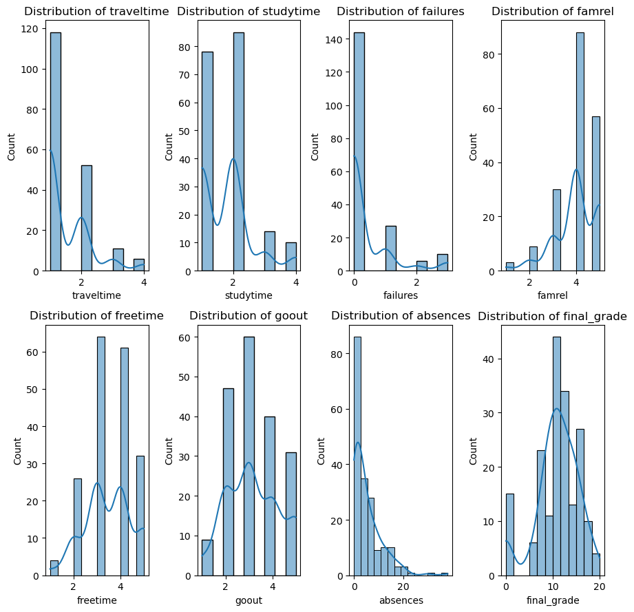

```python
#importing warnings module to turn off tight_layout warning by matplotlib
import warnings
warnings.filterwarnings('ignore')

#plotting distribution in a matrix fashion
rows=2
cols=4
plt.figure(figsize=(9,9))
for i,colname in enumerate(non_binary_cols):
    plt.subplot(rows,cols,i+1)
    sns.histplot(data=male_stud_df,x=colname,kde=True)
    plt.title('Distribution of '+colname)
    plt.tight_layout()
plt.show()
```

### Question 2

#### A : Loading female_stud.csv dataset

```python
female_stud_df=pd.read_csv('female_stud.csv')
female_stud_df.head()
```

|  | large_family | lives_in_city | traveltime | studytime | failures | paid | activities | internet | romantic | famrel | freetime | goout | absences | final_grade |
| --- | --- | --- | --- | --- | --- | --- | --- | --- | --- | --- | --- | --- | --- | --- |
| 0 | 1 | 1 | 2 | 2 | 0 | 0 | 0 | 0 | 0 | 4 | 3 | 4 | 6 | 6 |
| 1 | 1 | 1 | 1 | 2 | 0 | 0 | 0 | 1 | 0 | 5 | 3 | 3 | 4 | 6 |
| 2 | 0 | 1 | 1 | 2 | 3 | 1 | 0 | 1 | 0 | 4 | 3 | 2 | 10 | 10 |
| 3 | 1 | 1 | 1 | 3 | 0 | 1 | 1 | 1 | 1 | 3 | 2 | 2 | 2 | 15 |
| 4 | 1 | 1 | 1 | 2 | 0 | 1 | 0 | 0 | 0 | 4 | 3 | 2 | 4 | 10 |

#### B

Lets look at the statistical summary of the data using describe function.

```python
female_stud_df.describe()
```

|  | large_family | lives_in_city | traveltime | studytime | failures | paid | activities | internet | romantic | famrel | freetime | goout | absences | final_grade |
| --- | --- | --- | --- | --- | --- | --- | --- | --- | --- | --- | --- | --- | --- | --- |
| count | 208.000000 | 208.000000 | 208.000000 | 208.000000 | 208.000000 | 208.000000 | 208.000000 | 208.000000 | 208.000000 | 208.000000 | 208.000000 | 208.000000 | 208.000000 | 208.000000 |
| mean | 0.750000 | 0.788462 | 1.408654 | 2.278846 | 0.302885 | 0.519231 | 0.461538 | 0.817308 | 0.379808 | 3.894231 | 3.009615 | 3.028846 | 6.216346 | 9.966346 |
| std | 0.434057 | 0.409385 | 0.645551 | 0.791949 | 0.701683 | 0.500835 | 0.499721 | 0.387346 | 0.486510 | 0.894625 | 0.942760 | 1.089757 | 9.445819 | 4.622338 |
| min | 0.000000 | 0.000000 | 1.000000 | 1.000000 | 0.000000 | 0.000000 | 0.000000 | 0.000000 | 0.000000 | 1.000000 | 1.000000 | 1.000000 | 0.000000 | 0.000000 |
| 25% | 0.750000 | 1.000000 | 1.000000 | 2.000000 | 0.000000 | 0.000000 | 0.000000 | 1.000000 | 0.000000 | 3.750000 | 2.000000 | 2.000000 | 0.000000 | 8.000000 |
| 50% | 1.000000 | 1.000000 | 1.000000 | 2.000000 | 0.000000 | 1.000000 | 0.000000 | 1.000000 | 0.000000 | 4.000000 | 3.000000 | 3.000000 | 4.000000 | 10.000000 |
| 75% | 1.000000 | 1.000000 | 2.000000 | 3.000000 | 0.000000 | 1.000000 | 1.000000 | 1.000000 | 1.000000 | 4.000000 | 4.000000 | 4.000000 | 8.000000 | 13.000000 |
| max | 1.000000 | 1.000000 | 4.000000 | 4.000000 | 3.000000 | 1.000000 | 1.000000 | 1.000000 | 1.000000 | 5.000000 | 5.000000 | 5.000000 | 75.000000 | 19.000000 |

```python
#checking the number of rows in dataset
female_stud_df.shape[0]
```

```
208
```

The provided dataset contains records of **208** female students as clear from its shape and the count in the description summary. However,desciption summary may not always be accurate,as it considers the only non-null rows for the count.

We can verify if the both the datasets have identical columns and in the same order by constructing a boolean numpy array using column indices for both datasets and verifying if any **True** entry exists for the specified condition in the boolean array . The method is illustrated below:

```python
male_stud_df.columns!=female_stud_df.columns
```

```
array([False, False, False, False, False, False, False, False, False,
       False, False, False, False, False])
```

Note: This method can only be used if the two datasets have equal number of columns.Furthermore, if the order of columns in both the datasets is same then and then only we will get all elements of the boolean array as **False** according to the specified condition.

A better and more generalised method for checking whether two datasets have same columns or not is illustrated in the following defined function.

```python
def are_datasets_alike(df1,df2):
    #checking if datasets have equal number of columns
    if df1.shape[1]!=df2.shape[1]:
        return False

    for i in df1.columns:
        #if a column of df1 is not found in df2 return False
        if i not in df2.columns:
            return False
    #full execution of loop means df1 and df2 have identical columns
    return True

are_datasets_alike(male_stud_df,female_stud_df)
```

```
True
```

The result for whether the datasets are alike is **True** as expected.

#### C

Lets perform hypothesis testing using a t-test, for each of the measurements, to test whether any of the indicators differ between the male and the female groups. We will be using Mann-Whitney U test as we are unsure whether the sample is drawn from normal population or not.

```python
for colname in male_stud_df.columns:
    ttest_result=stats.mannwhitneyu(male_stud_df[colname],female_stud_df[colname])
    #printing the results of hypothesis
    print(colname,': t-statistic =',ttest_result[0],',p-value =','%.4f'%ttest_result[1])
```

```
large_family : t-statistic = 17862.0 ,p-value = 0.0746
lives_in_city : t-statistic = 18986.0 ,p-value = 0.5720
traveltime : t-statistic = 20301.0 ,p-value = 0.3700
studytime : t-statistic = 12462.5 ,p-value = 0.0000
failures : t-statistic = 20171.5 ,p-value = 0.3692
paid : t-statistic = 16942.0 ,p-value = 0.0104
activities : t-statistic = 21392.0 ,p-value = 0.0476
internet : t-statistic = 20089.0 ,p-value = 0.3816
romantic : t-statistic = 17573.5 ,p-value = 0.0429
famrel : t-statistic = 20826.5 ,p-value = 0.1884
freetime : t-statistic = 24363.0 ,p-value = 0.0000
goout : t-statistic = 20964.0 ,p-value = 0.1663
absences : t-statistic = 19261.5 ,p-value = 0.8675
final_grade : t-statistic = 21758.0 ,p-value = 0.0407
```

Null Hypothesis, $H_{0}$: The distributions of both groups are equal.

Alternate Hypothesis, $H_{1}$: The distributions of the two groups are not equal.

### Question 3

#### A

Lets combine the two dataframes which can be done using pd.concat function.

```python
combined_df=pd.concat([male_stud_df,female_stud_df],ignore_index=True)
combined_df.head()
```

|  | large_family | lives_in_city | traveltime | studytime | failures | paid | activities | internet | romantic | famrel | freetime | goout | absences | final_grade |
| --- | --- | --- | --- | --- | --- | --- | --- | --- | --- | --- | --- | --- | --- | --- |
| 0 | 0 | 1 | 1 | 2 | 0 | 1 | 1 | 1 | 0 | 5 | 4 | 2 | 10 | 15 |
| 1 | 0 | 1 | 1 | 2 | 0 | 0 | 0 | 1 | 0 | 4 | 4 | 4 | 0 | 11 |
| 2 | 0 | 1 | 1 | 2 | 0 | 1 | 0 | 1 | 0 | 4 | 2 | 2 | 0 | 19 |
| 3 | 1 | 1 | 1 | 2 | 0 | 1 | 1 | 1 | 0 | 5 | 5 | 1 | 0 | 15 |
| 4 | 0 | 1 | 1 | 1 | 0 | 1 | 1 | 1 | 0 | 4 | 3 | 3 | 2 | 14 |

Lets verify if the new dataframe has been created properly by seeing if the number of rows are equal to the sum of number of rows in each of the dataframes used to generate this one.

```python
combined_df.shape[0]==male_stud_df.shape[0]+female_stud_df.shape[0]
```

```
True
```

The result is true as expected.

#### B

We can generate a correlation matrix using corr() function of dataframe which returns a dataframe with correlation coefficients among all the variables(columns) in dataset.

```python
correlation_matrix=combined_df.corr()
correlation_matrix
```

|  | large_family | lives_in_city | traveltime | studytime | failures | paid | activities | internet | romantic | famrel | freetime | goout | absences | final_grade |
| --- | --- | --- | --- | --- | --- | --- | --- | --- | --- | --- | --- | --- | --- | --- |
| large_family | 1.000000 | -0.072472 | -0.063493 | 0.073595 | 0.015769 | 0.013882 | 0.000113 | -0.000720 | -0.034395 | 0.022776 | -0.017695 | -0.023064 | -0.035783 | -0.081407 |
| lives_in_city | -0.072472 | 1.000000 | -0.328096 | -0.020912 | -0.078578 | 0.052800 | -0.051360 | 0.216842 | 0.005257 | 0.014258 | 0.034878 | 0.068835 | -0.027874 | 0.105756 |
| traveltime | -0.063493 | -0.328096 | 1.000000 | -0.100909 | 0.092239 | -0.066420 | -0.007766 | -0.111302 | 0.021962 | -0.016808 | -0.017025 | 0.028540 | -0.012944 | -0.117142 |
| studytime | 0.073595 | -0.020912 | -0.100909 | 1.000000 | -0.173563 | 0.167220 | 0.089877 | 0.059422 | 0.053285 | 0.039731 | -0.143198 | -0.063904 | -0.062700 | 0.097820 |
| failures | 0.015769 | -0.078578 | 0.092239 | -0.173563 | 1.000000 | -0.188039 | -0.069341 | -0.063451 | 0.093137 | -0.044337 | 0.091987 | 0.124561 | 0.063726 | -0.360415 |
| paid | 0.013882 | 0.052800 | -0.066420 | 0.167220 | -0.188039 | 1.000000 | -0.021382 | 0.153132 | 0.005536 | 0.000460 | -0.064253 | 0.010493 | 0.007435 | 0.101996 |
| activities | 0.000113 | -0.051360 | -0.007766 | 0.089877 | -0.069341 | -0.021382 | 1.000000 | 0.048663 | 0.019651 | 0.040687 | 0.089728 | 0.046088 | -0.013610 | 0.016100 |
| internet | -0.000720 | 0.216842 | -0.111302 | 0.059422 | -0.063451 | 0.153132 | 0.048663 | 1.000000 | 0.087122 | 0.032768 | 0.051286 | 0.074370 | 0.101701 | 0.098483 |
| romantic | -0.034395 | 0.005257 | 0.021962 | 0.053285 | 0.093137 | 0.005536 | 0.019651 | 0.087122 | 1.000000 | -0.063816 | -0.011182 | 0.007870 | 0.153384 | -0.129970 |
| famrel | 0.022776 | 0.014258 | -0.016808 | 0.039731 | -0.044337 | 0.000460 | 0.040687 | 0.032768 | -0.063816 | 1.000000 | 0.150701 | 0.064568 | -0.044354 | 0.051363 |
| freetime | -0.017695 | 0.034878 | -0.017025 | -0.143198 | 0.091987 | -0.064253 | 0.089728 | 0.051286 | -0.011182 | 0.150701 | 1.000000 | 0.285019 | -0.058078 | 0.011307 |
| goout | -0.023064 | 0.068835 | 0.028540 | -0.063904 | 0.124561 | 0.010493 | 0.046088 | 0.074370 | 0.007870 | 0.064568 | 0.285019 | 1.000000 | 0.044302 | -0.132791 |
| absences | -0.035783 | -0.027874 | -0.012944 | -0.062700 | 0.063726 | 0.007435 | -0.013610 | 0.101701 | 0.153384 | -0.044354 | -0.058078 | 0.044302 | 1.000000 | 0.034247 |
| final_grade | -0.081407 | 0.105756 | -0.117142 | 0.097820 | -0.360415 | 0.101996 | 0.016100 | 0.098483 | -0.129970 | 0.051363 | 0.011307 | -0.132791 | 0.034247 | 1.000000 |

We need to find the largest 4 values excluding ones from this dataframe. Lets define a function for the same which will input the correlation matrix and a number n and return the n pairs of feature names in the form of tuple which are highly correlated alongwith their correlation coefficient.

```python
def findMaxCorrelatedFeatures(corr_mat,n):
    out=[]
    corr_mat=corr_mat[corr_mat!=1] #remove all the entries of self correlation
    #At each iteration of while loop the max correlated pair's information will be appended to the output list
    while n>0:
        max_val=float('-inf')
        temp=[None]*3
        #final max correlation value to be appended to output will be generated after the for loop
        for i in corr_mat.columns:
            #finding the position of max_correlation in series
            max_correlated_feature_index=corr_mat[i].abs().argmax()

            currentMax=abs(corr_mat[i][max_correlated_feature_index])
            if currentMax>max_val:
                max_val=currentMax
                temp[0]=i#column index
                temp[1]=corr_mat.columns[max_correlated_feature_index]#row index
                temp[2]=corr_mat[i][max_correlated_feature_index]#correlation coefficient

        out.append((temp[0],temp[1],temp[2]))#appending the final values in the output array

        #resetting the values in the correlation_matrix to zero for pairs added to output
        #this is being done to ensure that values already added to output are not considered in the next
        #iteration
        corr_mat.loc[temp[0],temp[1]]=corr_mat.loc[temp[1],temp[0]]=0
        n-=1

    return out

max_correlated_features=findMaxCorrelatedFeatures(correlation_matrix,4)
max_correlated_features
```

```
[('failures', 'final_grade', -0.36041494046164985),
 ('lives_in_city', 'traveltime', -0.32809550444575913),
 ('freetime', 'goout', 0.2850187149682024),
 ('lives_in_city', 'internet', 0.21684243568721276)]
```

The 4 topmost correlated pairs as from the output above:

- failures <-> final_grade
- lives_in_city <-> traveltime
- freetime <-> goout
- lives_in_city <-> internet

However, the correlation coefficients between the listed indicators seems to be low enough.Therefore, we can consider them to be weakly correlated.

We can also get a gist of correlation using scatterplots for these indicators.

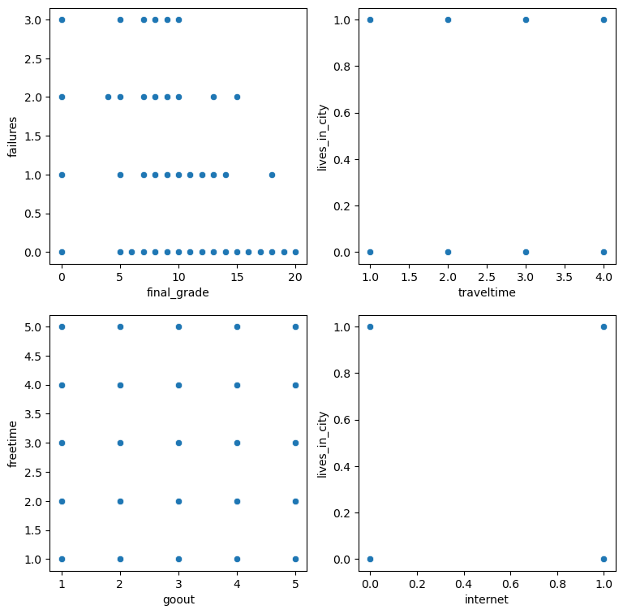

```python
plt.figure(figsize=(9,9))

for i in range(4):
    plt.subplot(2,2,i+1)
    sns.scatterplot(data=combined_df,x=max_correlated_features[i][1],y=max_correlated_features[i][0])
```

We had justified above that there is weak correlation according to correlation coefficients which can also be seen in the above scatterplots.

- In the first plot between **final grade** and **number of failures**, it is clear that all students in different categories of failures have a straight line relationship(constant:neither increasing nor decreasing,slope = 0) with final grade.
- In the second plot between **travel time** and **lives in city**, it is clear that travel time of students is having a straight line relationship irrespective of the fact whether a student lives in city or not.
- In the third plot between **go out** and **free time**, it is clear that students belonging to each category of free time have a straight line relationship with each category of go out. In other words, freetime is not highly correlated with going out as each of its category has evenly distributed students from all categories of go out. In layman terms,a student who doesn't have much free time may have any frequency of going out and the converse a student who has a greater level of free time may have any frequency of going out, both are true.
- In the fourth plot between **internet** and **lives in city**, it is clear that students belonging to each category of internet have a straight line relationship with each category of lives in city. In other words, a student who lives in city may or may not have internet and the converse i.e a student who doesn't live in city may or may not have internet, both are true.

### Question 4

#### A

In the Portuguese system a grade from 0 to 9.5 is considered as a FAIL, while grades from 10 to 20 are considered PASS.  
Lets create a new column in the dataframe indicating whether the student passed or failed.  
We can do this using cut function which will return a categorical series.

```python
bins=[-1,9.5,20]#-1 is used here so that grade of 0 can be included
labels=[0,1] # 0 for fail, 1 for pass
pass_fail_series=pd.cut(combined_df.final_grade,bins=bins,labels=labels,right=True)
pass_fail_series.value_counts()
```

```
final_grade
1    265
0    130
Name: count, dtype: int64
```

Lets assign the newly created categorical series to a new column in dataframe which will indicate whether the student passed or not.

```python
combined_df_Pass=combined_df.copy()
combined_df_Pass['Pass']=pass_fail_series
combined_df_Pass.tail()
```

|  | large_family | lives_in_city | traveltime | studytime | failures | paid | activities | internet | romantic | famrel | freetime | goout | absences | final_grade | Pass |
| --- | --- | --- | --- | --- | --- | --- | --- | --- | --- | --- | --- | --- | --- | --- | --- |
| 390 | 1 | 0 | 2 | 3 | 0 | 1 | 0 | 0 | 0 | 5 | 3 | 3 | 2 | 10 | 1 |
| 391 | 1 | 0 | 3 | 1 | 0 | 1 | 1 | 1 | 1 | 4 | 4 | 3 | 7 | 6 | 0 |
| 392 | 1 | 0 | 1 | 3 | 1 | 0 | 1 | 1 | 0 | 5 | 4 | 2 | 0 | 0 | 0 |
| 393 | 0 | 1 | 1 | 2 | 0 | 1 | 0 | 1 | 0 | 4 | 3 | 4 | 0 | 8 | 0 |
| 394 | 1 | 1 | 2 | 2 | 1 | 0 | 1 | 0 | 0 | 1 | 1 | 1 | 0 | 0 | 0 |

#### B

The column has been created successfully.  
Now, we can use this column as the response variable.  
But first lets split the dataset into response and predictors.

```python
response=combined_df_Pass.Pass.copy()
predictors=combined_df_Pass.drop(columns=['final_grade','Pass'])
predictors.head()
```

|  | large_family | lives_in_city | traveltime | studytime | failures | paid | activities | internet | romantic | famrel | freetime | goout | absences |
| --- | --- | --- | --- | --- | --- | --- | --- | --- | --- | --- | --- | --- | --- |
| 0 | 0 | 1 | 1 | 2 | 0 | 1 | 1 | 1 | 0 | 5 | 4 | 2 | 10 |
| 1 | 0 | 1 | 1 | 2 | 0 | 0 | 0 | 1 | 0 | 4 | 4 | 4 | 0 |
| 2 | 0 | 1 | 1 | 2 | 0 | 1 | 0 | 1 | 0 | 4 | 2 | 2 | 0 |
| 3 | 1 | 1 | 1 | 2 | 0 | 1 | 1 | 1 | 0 | 5 | 5 | 1 | 0 |
| 4 | 0 | 1 | 1 | 1 | 0 | 1 | 1 | 1 | 0 | 4 | 3 | 3 | 2 |

The next step is to standardize the predictors for which we'll be using normal standardization.

```python
predictors=(predictors-predictors.mean())/predictors.std()
predictors.describe()
```

|  | large_family | lives_in_city | traveltime | studytime | failures | paid | activities | internet | romantic | famrel | freetime | goout | absences |
| --- | --- | --- | --- | --- | --- | --- | --- | --- | --- | --- | --- | --- | --- |
| count | 3.950000e+02 | 395.000000 | 3.950000e+02 | 3.950000e+02 | 3.950000e+02 | 3.950000e+02 | 3.950000e+02 | 3.950000e+02 | 395.000000 | 3.950000e+02 | 3.950000e+02 | 3.950000e+02 | 3.950000e+02 |
| mean | -2.698264e-17 | 0.000000 | 1.304161e-16 | -2.518379e-16 | 1.798842e-17 | 5.396527e-17 | -1.079305e-16 | -2.023698e-17 | 0.000000 | -1.708900e-16 | 7.195369e-17 | -1.304161e-16 | -2.698264e-17 |
| std | 1.000000e+00 | 1.000000 | 1.000000e+00 | 1.000000e+00 | 1.000000e+00 | 1.000000e+00 | 1.000000e+00 | 1.000000e+00 | 1.000000 | 1.000000e+00 | 1.000000e+00 | 1.000000e+00 | 1.000000e+00 |
| min | -1.568015e+00 | -1.865423 | -6.424347e-01 | -1.233786e+00 | -4.493737e-01 | -9.185059e-01 | -1.016592e+00 | -2.229849e+00 | -0.707552 | -3.283640e+00 | -2.237990e+00 | -1.894280e+00 | -7.133316e-01 |
| 25% | -1.568015e+00 | 0.534714 | -6.424347e-01 | -1.233786e+00 | -4.493737e-01 | -9.185059e-01 | -1.016592e+00 | 4.473254e-01 | -0.707552 | 6.211528e-02 | -2.357113e-01 | -9.960321e-01 | -7.133316e-01 |
| 50% | 6.361343e-01 | 0.534714 | -6.424347e-01 | -4.223229e-02 | -4.493737e-01 | -9.185059e-01 | 9.811884e-01 | 4.473254e-01 | -0.707552 | 6.211528e-02 | -2.357113e-01 | -9.778397e-02 | -2.135250e-01 |
| 75% | 6.361343e-01 | 0.534714 | 7.912473e-01 | -4.223229e-02 | -4.493737e-01 | 1.085968e+00 | 9.811884e-01 | 4.473254e-01 | 1.409745 | 1.177367e+00 | 7.654280e-01 | 8.004641e-01 | 2.862816e-01 |
| max | 6.361343e-01 | 0.534714 | 3.658611e+00 | 2.340875e+00 | 3.584777e+00 | 1.085968e+00 | 9.811884e-01 | 4.473254e-01 | 1.409745 | 1.177367e+00 | 1.766567e+00 | 1.698712e+00 | 8.658042e+00 |

According to the numerical summary of predictors,the standard deviation for each predictor is one after normal standardization which is as expected.

#### C

We can fit a logistic regression model as the data has already been splitted into response and predictors.  
Before that we need to add a column of 1s as the first column which will represent the intercept term in predictor dataframe.  
We can do tha using sm.add_constant() functiom from statsmodels package.

```python
predictors_with_intercept=sm.add_constant(predictors)
predictors_with_intercept.head()
```

|  | const | large_family | lives_in_city | traveltime | studytime | failures | paid | activities | internet | romantic | famrel | freetime | goout | absences |
| --- | --- | --- | --- | --- | --- | --- | --- | --- | --- | --- | --- | --- | --- | --- |
| 0 | 1.0 | -1.568015 | 0.534714 | -0.642435 | -0.042232 | -0.449374 | 1.085968 | 0.981188 | 0.447325 | -0.707552 | 1.177367 | 0.765428 | -0.996032 | 0.536185 |
| 1 | 1.0 | -1.568015 | 0.534714 | -0.642435 | -0.042232 | -0.449374 | -0.918506 | -1.016592 | 0.447325 | -0.707552 | 0.062115 | 0.765428 | 0.800464 | -0.713332 |
| 2 | 1.0 | -1.568015 | 0.534714 | -0.642435 | -0.042232 | -0.449374 | 1.085968 | -1.016592 | 0.447325 | -0.707552 | 0.062115 | -1.236851 | -0.996032 | -0.713332 |
| 3 | 1.0 | 0.636134 | 0.534714 | -0.642435 | -0.042232 | -0.449374 | 1.085968 | 0.981188 | 0.447325 | -0.707552 | 1.177367 | 1.766567 | -1.894280 | -0.713332 |
| 4 | 1.0 | -1.568015 | 0.534714 | -0.642435 | -1.233786 | -0.449374 | 1.085968 | 0.981188 | 0.447325 | -0.707552 | 0.062115 | -0.235711 | -0.097784 | -0.463428 |

Fitting the logistic regression model using all the predictors.

```python
log_model1 = sm.Logit(response, predictors_with_intercept).fit()
#Viewing the model summary
print("AIC =",log_model1.aic)
print(log_model1.summary())
```

```
Optimization terminated successfully.
         Current function value: 0.556201
         Iterations 5
AIC = 467.3988728177466
                           Logit Regression Results
==============================================================================
Dep. Variable:                   Pass   No. Observations:                  395
Model:                          Logit   Df Residuals:                      381
Method:                           MLE   Df Model:                           13
Date:                Sun, 10 Dec 2023   Pseudo R-squ.:                  0.1221
Time:                        11:45:21   Log-Likelihood:                -219.70
converged:                       True   LL-Null:                       -250.25
Covariance Type:            nonrobust   LLR p-value:                 3.330e-08
=================================================================================
                    coef    std err          z      P>|z|      [0.025      0.975]
---------------------------------------------------------------------------------
const             0.7801      0.118      6.602      0.000       0.548       1.012
large_family     -0.1204      0.121     -0.998      0.318      -0.357       0.116
lives_in_city     0.0507      0.125      0.404      0.686      -0.195       0.297
traveltime        0.0063      0.126      0.050      0.960      -0.241       0.254
studytime         0.0400      0.125      0.320      0.749      -0.205       0.285
failures         -0.6692      0.130     -5.132      0.000      -0.925      -0.414
paid              0.0768      0.121      0.633      0.527      -0.161       0.315
activities       -0.0269      0.119     -0.226      0.821      -0.260       0.206
internet          0.1361      0.119      1.147      0.251      -0.096       0.369
romantic         -0.1623      0.117     -1.383      0.167      -0.392       0.068
famrel            0.0644      0.118      0.547      0.584      -0.166       0.295
freetime          0.1361      0.126      1.079      0.280      -0.111       0.383
goout            -0.4254      0.127     -3.344      0.001      -0.675      -0.176
absences         -0.1279      0.111     -1.149      0.250      -0.346       0.090
=================================================================================
```

Interpretation for the logistic regression model considering all the predictors:

- large_family: A unit increase in large_family predictor keeping all other predictors fixed will decrease the log(odds of passing) by 0.1204 units. Another thing to note here is that the p-value is above 0.05 (considering a significance level of 5%) which indicates that this variable is not statistically significant in predicting the odds of passing.
- lives_in_city: A unit increase in lives_in_city predictor keeping all other predictors fixed will increase the log(odds of passing) by 0.0507 units. Another thing to note here is that the p-value is above 0.05 (considering a significance level of 5%) which indicates that this variable is not statistically significant in predicting the odds of passing either.
- traveltime: A unit increase in traveltime predictor keeping all other predictors fixed will increase the log(odds of passing) by 0.0063 units. Another thing to note here is that the p-value is above 0.05 (considering a significance level of 5%) which indicates that this variable is not statistically significant in predicting the odds of passing either.
- studytime: A unit increase in studytime predictor keeping all other predictors fixed will increase the log(odds of passing) by 0.04 units. Another thing to note here is that the p-value is above 0.05 (considering a significance level of 5%) which indicates that this variable is not statistically significant in predicting the odds of passing either.
- failures: A unit increase in failures predictor keeping all other predictors fixed will decrease the log(odds of passing) by 0.6692 units. Another thing to note here is that the p-value is below 0.05 (considering a significance level of 5%) which indicates that this variable is statistically significant in predicting the odds of passing.
- paid: A unit increase in paid predictor keeping all other predictors fixed will increase the log(odds of passing) by 0.0768 units. Another thing to note here is that the p-value is above 0.05 (considering a significance level of 5%) which indicates that this variable is not statistically significant in predicting the odds of passing either.
- activities: A unit increase in activities predictor keeping all other predictors fixed will decrease the log(odds of passing) by 0.0269 units. Another thing to note here is that the p-value is above 0.05 (considering a significance level of 5%) which indicates that this variable is not statistically significant in predicting the odds of passing.
- internet: A unit increase in internet predictor keeping all other predictors fixed will increase the log(odds of passing) by 0.1361 units. Another thing to note here is that the p-value is above 0.05 (considering a significance level of 5%) which indicates that this variable is not statistically significant in predicting the odds of passing either.
- romantic: A unit increase in romantic predictor keeping all other predictors fixed will decrease the log(odds of passing) by 0.1623 units. Another thing to note here is that the p-value is above 0.05 (considering a significance level of 5%) which indicates that this variable is not statistically significant in predicting the odds of passing either.
- famrel: A unit increase in famrel predictor keeping all other predictors fixed will increase the log(odds of passing) by 0.0644 units. Another thing to note here is that the p-value is above 0.05 (considering a significance level of 5%) which indicates that this variable is not statistically significant in predicting the odds of passing either.
- freetime: A unit increase in freetime predictor keeping all other predictors fixed will increase the log(odds of passing) by 0.13610.0644 units. Another thing to note here is that the p-value is above 0.05 (considering a significance level of 5%) which indicates that this variable is not statistically significant in predicting the odds of passing either.
- goout: A unit increase in goout predictor keeping all other predictors fixed will decrease the log(odds of passing) by 0.4254 units. Another thing to note here is that the p-value is below 0.05 (considering a significance level of 5%) which indicates that this variable is statistically significant in predicting the odds of passing either.
- absences: A unit increase in absences predictor keeping all other predictors fixed will decrease the log(odds of passing) by 0.1279 units. Another thing to note here is that the p-value is above 0.05 (considering a significance level of 5%) which indicates that this variable is not statistically significant in predicting the odds of passing either.

#### D

Defining a function for forward selection of predictors using AIC as the criteria.  
The function defined below takes in 2 parameters:

1. The predictors dataframe with intercept column added
2. The series of response data.  
   This function outputs a list of positions corresponding to best predictors selected in the transformed dataframe passed i.e. predictors dataframe with intercept columns.  
   Note: The list of positions returned includes the position of intercept column as well at the 0th index.

```python
def forwardAIC(covariates,response):
    #will only work if the intercept term is already present at the first position in covariates dataframe
    ind=0
    column_indexes=[ind]#index of intercept, for initialization step of null model
    # this flag will indicate whether a subset of covariates that decreases AIC is found
    # if true,the loop continues to run and checks for further subsets that decrease AIC
    # if at any point in time the AIC is not reducing further then the loop ends

    flag=True #initializing as True for the first run of while loop

    while(flag):#loop terminated when flag is false
        maxDecreaseAIC=float('-inf')
        flag=False #toggled to false
        curr_mod = sm.Logit(response,covariates.iloc[:,column_indexes])
        curr_res = curr_mod.fit(disp=0)# silencing "Optimization Termination" output using "disp" param

        for j in range(covariates.shape[1]):
            if (j not in column_indexes):
                new_mod=sm.Logit(response,covariates.iloc[:,column_indexes + [j]])
                new_res=new_mod.fit(disp=0)
                difference_aic=curr_res.aic-new_res.aic
                if (difference_aic > 0 and difference_aic>maxDecreaseAIC):
                    maxDecreaseAIC=difference_aic
                    ind=j
                    flag=True
        if (flag):#if true append the column index
            column_indexes.append(ind)

    return column_indexes#includes the intercept


selected_cols=forwardAIC(predictors_with_intercept,response)
```

Lets check which predictors have been selected by forward selection using AIC.

```python
forward_selected_cols=list(predictors_with_intercept.columns[selected_cols])
forward_selected_cols
```

```
['const', 'failures', 'goout']
```

Fitting the model using the features selected through forward AIC selection process.

```python
log_model2 = sm.Logit(response, predictors_with_intercept[forward_selected_cols]).fit()
#Viewing the model summary
print("AIC =",log_model2.aic)
print(log_model2.summary())
```

```
Optimization terminated successfully.
         Current function value: 0.566845
         Iterations 5
AIC = 453.80718068224115
                           Logit Regression Results
==============================================================================
Dep. Variable:                   Pass   No. Observations:                  395
Model:                          Logit   Df Residuals:                      392
Method:                           MLE   Df Model:                            2
Date:                Sun, 10 Dec 2023   Pseudo R-squ.:                  0.1053
Time:                        11:45:22   Log-Likelihood:                -223.90
converged:                       True   LL-Null:                       -250.25
Covariance Type:            nonrobust   LLR p-value:                 3.606e-12
==============================================================================
                 coef    std err          z      P>|z|      [0.025      0.975]
------------------------------------------------------------------------------
const          0.7530      0.116      6.504      0.000       0.526       0.980
failures      -0.7187      0.129     -5.587      0.000      -0.971      -0.467
goout         -0.3547      0.118     -3.017      0.003      -0.585      -0.124
==============================================================================
```

Interpretation for the newly constructed logistic regression model :

- failures: A unit increase in failures predictor keeping all other predictors fixed will decrease the log(odds of passing) by 0.7187 units. Another thing to note here is that the p-value is below 0.05 (considering a significance level of 5%) which indicates that this variable is statistically significant in predicting the odds of passing.
- goout: A unit increase in goout predictor keeping all other predictors fixed will decrease the log(odds of passing) by 0.3547 units. Another thing to note here is that the p-value is below 0.05 (considering a significance level of 5%) which indicates that this variable is statistically significant in predicting the odds of passing either.

An interesting thing to notice here is that in the earlier model, predicters **failures** and **goout** were statistically significant according to their respective p values in the model summary and the forward selection process also filtered out these two predictors as best among all the predictors according to AIC value which makes sense statistically speaking.

### Question 5

#### A

Lets split the dataset into train and test splits with 75% and 25% proportions respectively.  
Note: throughout the code we will use random state of 101 to ensure reproducability.

```python
from sklearn.model_selection import train_test_split

x=combined_df.drop('final_grade',axis=1)
y=combined_df['final_grade']
xTrain, xTest, yTrain, yTest = train_test_split(x, y, test_size=0.25, random_state=101)
```

#### B

Now, we will fit a Random Forest Regression Model with 10 trees using the training data.

```python
from sklearn.ensemble import RandomForestRegressor
model3 = RandomForestRegressor(n_estimators=10,random_state=101)# n_estimators : no. of trees
model3.fit(xTrain, yTrain)
```

```
RandomForestRegressor(n_estimators=10, random_state=101)
```

```python
# Get important predictors
predictor_importances = pd.DataFrame({'Predictor': xTrain.columns, 'Importance': model3.feature_importances_})

# Sort predictors by importance (descending order)
predictor_importances = predictor_importances.sort_values(by='Importance', ascending=False).reset_index(drop=True)

# View the importance of each predictor
print(predictor_importances)
```

```
        Predictor  Importance
0        absences    0.233288
1        failures    0.177896
2           goout    0.110746
3        freetime    0.104786
4          famrel    0.093004
5       studytime    0.073079
6      traveltime    0.045742
7    large_family    0.034065
8      activities    0.032815
9        romantic    0.032057
10           paid    0.030876
11  lives_in_city    0.018962
12       internet    0.012683
```

According to the generated predictor importance score summary:

- Predictor **absences** emerged as most important predictor with 23.3% importance ,this suggests that the attendance of students play a major role in their final grade.
- Predictor **failures** emerged as secondmost important predictor with 17.7% importance ,this suggests that the past failures of students play a significant role in their final grade.
- Predictor **goout** emerged as thirdmost important predictor with approximately 11% importance ,this suggests that the frequency of going out of students play a significant role in their final grade.
- Predictor **freetime** emerged as fourthmost important predictor with approximately 10% importance ,this suggests that the past failures of students play a significant role in their final grade.
- The rest of the predictors have either low(importance score < 0.5) or moderate(0.5 <= importance score < 0.1) importance score.

Comparing the random forest regression model with logistic regression model, we observe:

- Predictors **goout** and **failures** again emerged as important or statistically significant predictors for predicting final grade of a student.
- Two new important predictors namely **absences** and **freetime** have emerged as important or statistically significant predictors according to the random forest regression model.
- One thing to note here is that predictor **absence** wasn't considered as important in the logistic model but here it is the most important covariate which is contributing significantly to the model.

#### C

Now, we will predict the final grades of student in the test set using the fitted random forest regression model.  
We can plot the predicted values of response with their true values along with the line y=x to get some understanding of deviations or prediction errors from true values.

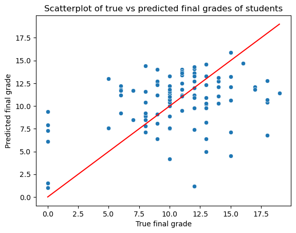

```python
#predictions
yPred = model3.predict(xTest)

#Creating scatterplot of true values vs predicted values
sns.scatterplot(x=yTest, y=yPred)

#plotting y=x line based on min and max value considering both test and train sets to ensure full coverage
# of plot
axis_min=min(min(yTest),min(yPred))
axis_max=max(max(yTest),max(yTest))
sns.lineplot(x=[axis_min,axis_max], y=[axis_min,axis_max], color='red')

#setting plot titles and axis labels
plt.xlabel("True final grade")
plt.ylabel("Predicted final grade")
plt.title('Scatterplot of true vs predicted final grades of students')
plt.show()
```

From the plot , we can conclude a few things:

- the model seems to overestimate predicted final grade for true grades below 12.5 and underestimate predicted final grade for true grades above 12.5.
- Overall the distribution of data points around the line y=x seems to be mostly even(symmetric) around the center. However, some datapoints are quite far away from the perfect regression line at the extremities and predictions for those extreme points seem unlikely after comparing with true values which might be happening due to presence of outliers.

#### D

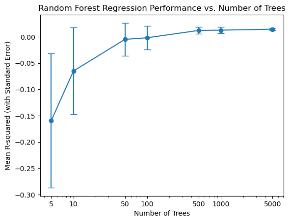

```python
from sklearn.metrics import r2_score

# defining the list of tree
num_trees_list = [5, 10, 50, 100, 500, 1000, 5000]
n = len(num_trees_list)

# Initialize zero arrays with size n for storing means of r_squared and its standard error
mean_r_squared = np.zeros(n)
std_r_squared = np.zeros(n)

# Loop over different numbers of trees
for i, num_trees_value in enumerate(num_trees_list):

    # Initialize zero to store r_squared for each iteration
    r_squared_values = np.zeros(20)

    # Repeat the model fitting and prediction
    for j in range(20):  # fit the model 20 times and store r_squared_value
        model = RandomForestRegressor(n_estimators=num_trees_value, random_state=j*2)

        # Fit the model to the training data
        model.fit(xTrain, yTrain)

        # Make predictions on the test set
        yPred = model.predict(xTest)

        # Calculate R-squared value
        r_squared_values[j] = r2_score(yTest, yPred)

    mean_r_squared[i] = np.mean(r_squared_values)
    std_r_squared[i] = np.std(r_squared_values)

# Plot the results
plt.errorbar(num_trees_list, mean_r_squared, yerr=std_r_squared, fmt='o-', capsize=5)
plt.xscale('log')  # Log scale for the number of trees
plt.xticks(num_trees_list, [str(num) for num in num_trees_list])#change the ticks to represent actual number of trees
plt.xlabel('Number of Trees')
plt.ylabel('Mean R-squared (with Standard Error)')
plt.title('Random Forest Regression Performance vs. Number of Trees')
plt.show()
```

Its clear from the plot between model performance and number of trees ,that as the number of trees are increasing the mean of r_squared values is increasing alongwith a decrease in standard error for means of r_squared values. Another important thing to notice here is that the standard error as well as the r_squared values remains constant starting from **500 trees**.

#### E

Fitting the model multiple times with different random states is essentialy useful if we wanna test the robustness and generalizability of model. Also, the rationale for doing so lies in the fact that due to randomness in selecting features at each split in this technique ,some amount of variability is introduced in the model. Therefore, fitting the model multiple times can help in providing insights into the stability and robustness of the model across different initializations.

### Question 6

#### A

Now. Lets try to cluster datapoints using a widely used technique called **K-Means Clustering**.

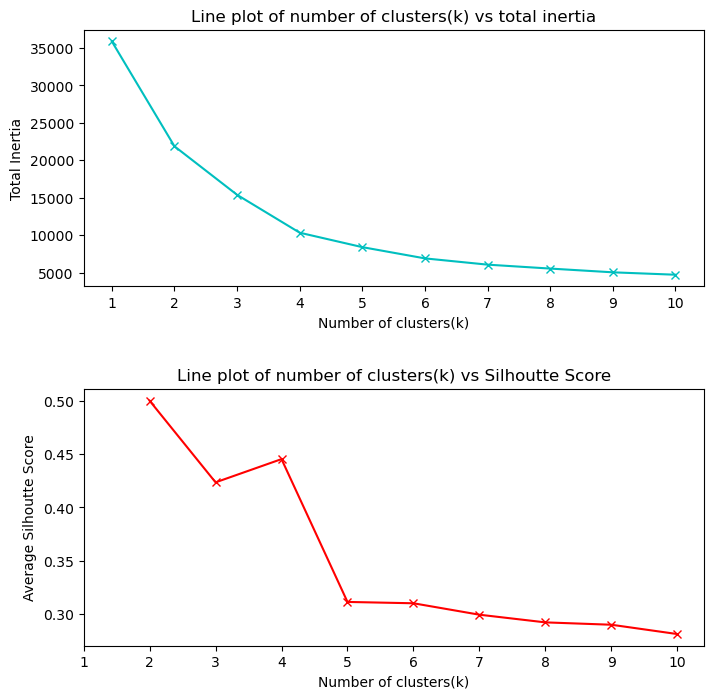

```python
from sklearn.cluster import KMeans
from sklearn.metrics import silhouette_score

k=list(range(1,11))
silhoutte_score_list=[]
#this is the sum of squared distances of each datapoint from the center of their respective clusters.
euclidean_dist_sum=[]

for i in k:
    model = KMeans(n_clusters=i,random_state=101)
    model.fit(combined_df)
    euclidean_dist_sum.append(model.inertia_)# inertia represents total sum of squared distances

    if i!=1:#silhoutte_score is not defined on a single cluster
        silhoutte_score_list.append(silhouette_score(combined_df, model.labels_))

plt.figure(figsize=(8,8))
plt.subplot(2,1,1)
plt.plot(k,euclidean_dist_sum,'cx-',)
plt.title("Line plot of number of clusters(k) vs total inertia")
plt.ylabel("Total Inertia")
plt.xlabel("Number of clusters(k)")
plt.xticks(k)
plt.subplot(2,1,2)
plt.plot(k[1:],silhoutte_score_list,'rx-',)
plt.title("Line plot of number of clusters(k) vs Silhoutte Score")
plt.ylabel("Average Silhoutte Score")
plt.xlabel("Number of clusters(k)")
plt.xticks(k)
plt.subplots_adjust(hspace=0.4)#Adjusting the vertical distance between subplots
plt.show()
```

We have used **Elbow method** first to get some understanding of the optimal value of k. In this method we plot inertias for models against different values of k and see the point after which there is not a significant decrease in inertia values. The line plot around ideal candidates of k would have an elbow like formation.

As can be seen from the plot,the inertia for the model dropped suddenly (elbow like formation) for values of k in the range [4-6] and is not dropping much post k=6. Therefore the potential candidates for optimal k are: 4, 5, 6

The second approach that we used to enforce our claim about range of optimal k was **Average Silhoutte Score analysis** for different values of k and and filter out a value of k from the range of k found earlier by analysing **inertia** values which gives the maximum **Average Silhoutte Score**.

Silhoutte score gives a measure of how similar a datapoint is within a cluster compared to other clusters or its compactness . The values of Silhoutte score range from -1 to 1 where, a score of 1 denotes that the datapoint is compact and close to the centroid of the cluster and far away from other clusters, and a score of -1 is worst which depicts that the clusters are overlapping.

From the plot between number of clusters(k) Vs average Silhoutte score, it is clear that k=4 is the optimal number of clusters for this data following the approach explained above.

#### B

```python
optimal_k=4
finalmodel = KMeans(n_clusters=optimal_k,random_state=101)
labels=finalmodel.fit_predict(combined_df)
labels#making predictions on data to see cluster labels
```

```
array([1, 0, 0, 0, 0, 0, 0, 1, 0, 0, 0, 0, 0, 0, 0, 0, 1, 0, 0, 0, 0, 0,
       0, 0, 0, 0, 0, 0, 0, 0, 0, 0, 0, 0, 0, 0, 0, 0, 0, 0, 0, 0, 1, 1,
       0, 0, 1, 0, 0, 0, 0, 0, 0, 0, 0, 0, 0, 0, 1, 0, 0, 1, 0, 3, 0, 3,
       3, 0, 3, 0, 3, 3, 0, 3, 0, 3, 0, 0, 0, 0, 3, 0, 3, 0, 0, 1, 0, 3,
       0, 0, 0, 0, 1, 0, 1, 0, 1, 0, 0, 0, 1, 0, 0, 0, 0, 1, 1, 1, 0, 0,
       1, 0, 1, 0, 1, 1, 0, 3, 1, 0, 3, 0, 0, 0, 1, 0, 0, 0, 0, 0, 0, 0,
       0, 1, 0, 0, 0, 1, 0, 1, 0, 1, 0, 1, 1, 0, 0, 0, 1, 0, 0, 0, 0, 1,
       0, 2, 0, 0, 0, 0, 0, 0, 3, 1, 0, 0, 1, 0, 0, 0, 0, 0, 0, 0, 0, 0,
       0, 0, 0, 0, 3, 1, 1, 0, 0, 0, 0, 0, 0, 1, 0, 0, 0, 0, 0, 0, 0, 0,
       0, 1, 3, 0, 0, 1, 1, 0, 1, 0, 0, 0, 0, 0, 0, 0, 0, 0, 0, 0, 0, 0,
       0, 0, 0, 1, 3, 2, 0, 1, 1, 0, 0, 0, 0, 0, 0, 0, 0, 0, 0, 0, 0, 1,
       1, 0, 0, 0, 0, 0, 0, 0, 0, 0, 3, 3, 1, 1, 3, 3, 0, 0, 0, 0, 3, 0,
       0, 0, 0, 0, 3, 0, 3, 0, 0, 0, 2, 1, 0, 1, 0, 0, 1, 0, 0, 0, 0, 1,
       0, 1, 0, 1, 0, 0, 1, 0, 1, 0, 1, 0, 0, 3, 3, 0, 0, 1, 1, 1, 1, 1,
       0, 3, 0, 3, 1, 0, 3, 0, 3, 1, 0, 0, 0, 0, 2, 1, 0, 0, 0, 0, 0, 0,
       1, 0, 3, 1, 0, 1, 0, 0, 0, 1, 3, 1, 1, 1, 2, 3, 1, 0, 0, 1, 1, 0,
       0, 0, 0, 0, 0, 3, 3, 3, 1, 1, 3, 0, 0, 0, 3, 0, 0, 0, 0, 0, 0, 0,
       0, 0, 0, 0, 3, 0, 1, 0, 0, 1, 0, 0, 0, 0, 0, 1, 0, 0, 3, 0, 3],
      dtype=int32)
```

```python
combined_df_clustering1=pd.concat([combined_df, pd.Series(labels,name='Cluster')], axis=1)
combined_df_clustering1.head()
```

|  | large_family | lives_in_city | traveltime | studytime | failures | paid | activities | internet | romantic | famrel | freetime | goout | absences | final_grade | Cluster |
| --- | --- | --- | --- | --- | --- | --- | --- | --- | --- | --- | --- | --- | --- | --- | --- |
| 0 | 0 | 1 | 1 | 2 | 0 | 1 | 1 | 1 | 0 | 5 | 4 | 2 | 10 | 15 | 1 |
| 1 | 0 | 1 | 1 | 2 | 0 | 0 | 0 | 1 | 0 | 4 | 4 | 4 | 0 | 11 | 0 |
| 2 | 0 | 1 | 1 | 2 | 0 | 1 | 0 | 1 | 0 | 4 | 2 | 2 | 0 | 19 | 0 |
| 3 | 1 | 1 | 1 | 2 | 0 | 1 | 1 | 1 | 0 | 5 | 5 | 1 | 0 | 15 | 0 |
| 4 | 0 | 1 | 1 | 1 | 0 | 1 | 1 | 1 | 0 | 4 | 3 | 3 | 2 | 14 | 0 |

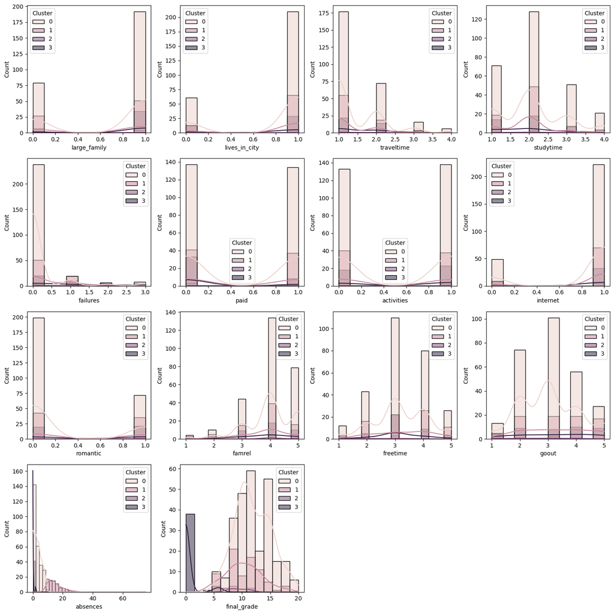

```python
plt.figure(figsize=(15,15))
for i,colname in enumerate(combined_df_clustering1.columns[:-1]):
    plt.subplot(4,4,i+1)
    sns.histplot(data=combined_df_clustering1,x=colname,hue='Cluster',kde=True)
    plt.tight_layout()
```

It is clear from the distribution plots, that the most discriminatory variables are :

- **final_grade**
- **absences**
- **freetime**
- **studytime**
- **failures**

These variables were selected as most discriminatory because their distribution across different clusters were significantly different from one another.

#### C

We can plot and see the cluster formation for data points by plotting them against the final_grade(response) variable.

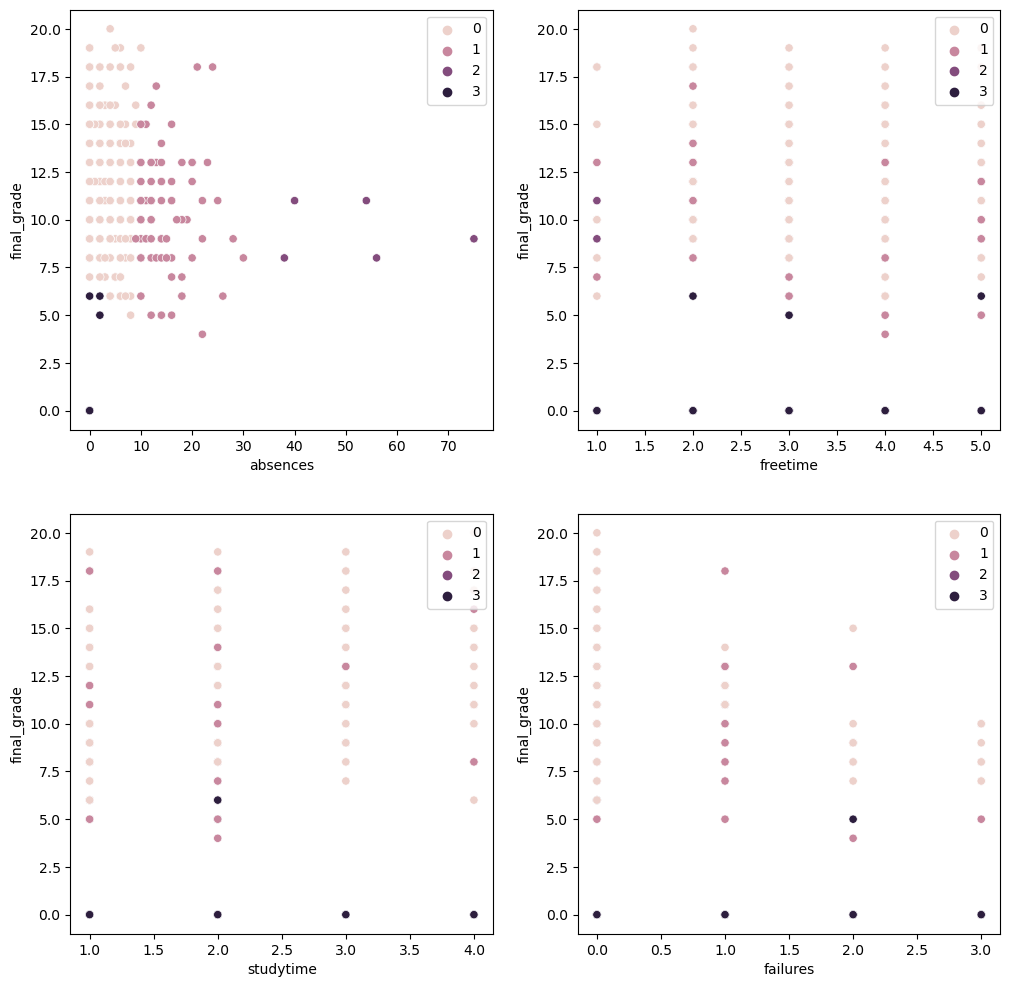

```python
discriminatory_cols=['absences','freetime','studytime','failures']
plt.figure(figsize=(12,12))
for i,col in enumerate(discriminatory_cols):
    plt.subplot(2,2,i+1)
    sns.scatterplot(data=combined_df_clustering1,x=col,y='final_grade',hue='Cluster').legend(loc='upper right')
    plt
plt.show()
```

As clear from the output above, the only interpretable scatterplot which is showing clustering clearly is the first graph, which is expected because all the other discriminatory variables except for **final_grade** and **absences** are discrete in nature.  
Furthermore, distinct cluster formations can be seen in the first plot which suggests that the dataset contains multiple categories of students with different characteristics.

#### D

We will be using **HDBSCAN (Hierarchical Density-Based Spatial Clustering of Applications with Noise)** for clustering the data. This techique can discover clusters of varying shapes and densities and it doesn't require us to specify the number of clusters that we want to create beforehand. Rather, it asks for **min_cluster_size** as input which specifies the minimum number of datapoints which need to be grouped together in order to form a cluster.

Since, we cannot specify number of clusters we want to construct we will simply fit the model using values of **min_cluster_size** over a range and see which one fits the model best.

Note: We can only test the models effectiveness using **Silhoutte score** as HDBscan considers density of points for selecting clusters rather than minimising the sum of squared distances from centroid.

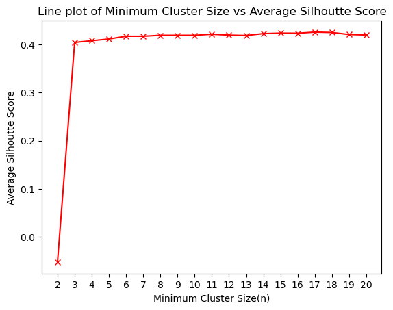

```python
# importing library for HDBSCAN
from sklearn.cluster import HDBSCAN
# k: number of clusters not applicable
min_cluster_size_list=list(range(2,21))

silhoutte_score_list=[]

for i in min_cluster_size_list:
    model = HDBSCAN(min_cluster_size=i)
    model.fit(combined_df)
    silhoutte_score_list.append(silhouette_score(combined_df, model.labels_))


plt.plot(min_cluster_size_list,silhoutte_score_list,'rx-',)
plt.title("Line plot of Minimum Cluster Size vs Average Silhoutte Score")
plt.ylabel("Average Silhoutte Score")
plt.xlabel("Minimum Cluster Size(n)")
plt.xticks(min_cluster_size_list)
plt.subplots_adjust(hspace=0.4)#Adjusting the vertical distance between subplots
plt.show()
```

Its clear from the above plot that **Silhoutte score** suffers a sharp increase as min_cluster_size jumps from 2 to 3 and remains approximately constant after that.

The **Silhoutte score** in context of **HDBScan** has different interpretation which is listed below : -

- A score near 1 suggests that datapoint within a cluster are far away from other clusters.
- A score of 0 signifies datapoint is very close to the decision boundary within a cluster.
- A negative score indicates that the data point is closer to the neighboring cluster than to its own assigned cluster which suggests that the point might be more fitting in another cluster and its current assignment is less appropriate.
- Note: The range of **Silhoutte Score** is in the range [-1,1] .

Since, the **Silhoutte score** seemed approximately constant after **min_cluster_size = 2**, we can filter out the min_cluster_size which was giving us the best model fit using the list of silhoutte score that we created earlier and use it to fit the best mode.  
The implementation is shown below:

```python
#computing the index in min_cluster_size_list which corresponds to max silhoutte score
optimal_min_cluster_size=min_cluster_size_list[np.array(silhoutte_score_list).argmax()]
finalmodel = HDBSCAN(min_cluster_size=optimal_min_cluster_size)
labels=finalmodel.fit_predict(combined_df)
labels#making predictions on data to see cluster labels
```

```
array([ 0,  0,  0,  0,  0,  0,  0, -1,  0,  0,  0,  0,  0,  0,  0,  0,  0,
        0,  0,  0,  0,  0,  0,  0,  0,  0,  0,  0,  0,  0,  0,  0,  0,  0,
        0,  0,  0,  0,  0,  0,  0,  0,  0, -1,  0,  0,  0,  0,  0,  0,  0,
        0,  0, -1,  0,  0,  0,  0, -1,  0,  0, -1,  0,  1,  0,  1,  1,  0,
        1,  0,  1,  1,  0,  1,  0,  1,  0,  0,  0,  0,  1,  0,  1,  0,  0,
        0,  0,  1,  0,  0,  0,  0,  0,  0,  0,  0,  0,  0,  0,  0,  0,  0,
        0,  0,  0,  0,  0,  0,  0,  0,  0,  0,  0,  0, -1,  0,  0,  1,  0,
        0,  1,  0,  0,  0,  0,  0,  0,  0,  0,  0,  0,  0,  0,  0,  0,  0,
        0, -1,  0,  0,  0, -1,  0, -1,  0,  0,  0,  0,  0,  0,  0,  0,  0,
       -1,  0, -1,  0,  0,  0,  0,  0,  0,  1,  0,  0,  0,  0,  0,  0,  0,
        0,  0,  0,  0,  0,  0,  0,  0,  0,  0,  1,  0,  0,  0,  0,  0,  0,
        0,  0,  0,  0,  0,  0,  0,  0,  0,  0,  0,  0,  0,  0,  0,  0, -1,
        0,  0,  0,  0,  0,  0,  0,  0,  0,  0,  0,  0,  0,  0,  0,  0,  0,
        0,  0,  0,  0, -1,  0,  0,  0,  0,  0,  0,  0,  0,  0,  0,  0,  0,
        0,  0,  0, -1,  0,  0,  0,  0,  0,  0,  0,  0,  0,  0,  1,  1,  0,
        0,  1,  1,  0,  0,  0,  0,  1,  0,  0,  0,  0,  0,  1,  0,  1,  0,
        0,  0, -1,  0,  0,  0,  0,  0, -1,  0,  0,  0,  0, -1,  0, -1,  0,
        0,  0,  0,  0,  0,  0,  0, -1,  0,  0,  0,  1,  0,  0,  0,  0,  0,
        0, -1,  0,  1,  0,  1, -1,  0,  1,  0,  1,  0,  0,  0,  0,  0, -1,
        0,  0,  0,  0,  0,  0,  0,  0,  0,  1,  0,  0,  0,  0,  0,  0,  0,
        1, -1, -1,  0, -1,  1,  0,  0,  0, -1,  0,  0,  0,  0,  0,  0,  0,
        1,  1,  1, -1,  0,  1,  0,  0,  0,  1,  0,  0,  0,  0,  0,  0,  0,
        0,  0,  0,  0,  1,  0,  0,  0,  0,  0,  0,  0,  0,  0,  0,  0,  0,
        0,  1,  0,  1])
```

```python
combined_df_clustering2=pd.concat([combined_df, pd.Series(labels,name='Cluster')], axis=1)
combined_df_clustering2.tail()
```

|  | large_family | lives_in_city | traveltime | studytime | failures | paid | activities | internet | romantic | famrel | freetime | goout | absences | final_grade | Cluster |
| --- | --- | --- | --- | --- | --- | --- | --- | --- | --- | --- | --- | --- | --- | --- | --- |
| 390 | 1 | 0 | 2 | 3 | 0 | 1 | 0 | 0 | 0 | 5 | 3 | 3 | 2 | 10 | 0 |
| 391 | 1 | 0 | 3 | 1 | 0 | 1 | 1 | 1 | 1 | 4 | 4 | 3 | 7 | 6 | 0 |
| 392 | 1 | 0 | 1 | 3 | 1 | 0 | 1 | 1 | 0 | 5 | 4 | 2 | 0 | 0 | 1 |
| 393 | 0 | 1 | 1 | 2 | 0 | 1 | 0 | 1 | 0 | 4 | 3 | 4 | 0 | 8 | 0 |
| 394 | 1 | 1 | 2 | 2 | 1 | 0 | 1 | 0 | 0 | 1 | 1 | 1 | 0 | 0 | 1 |

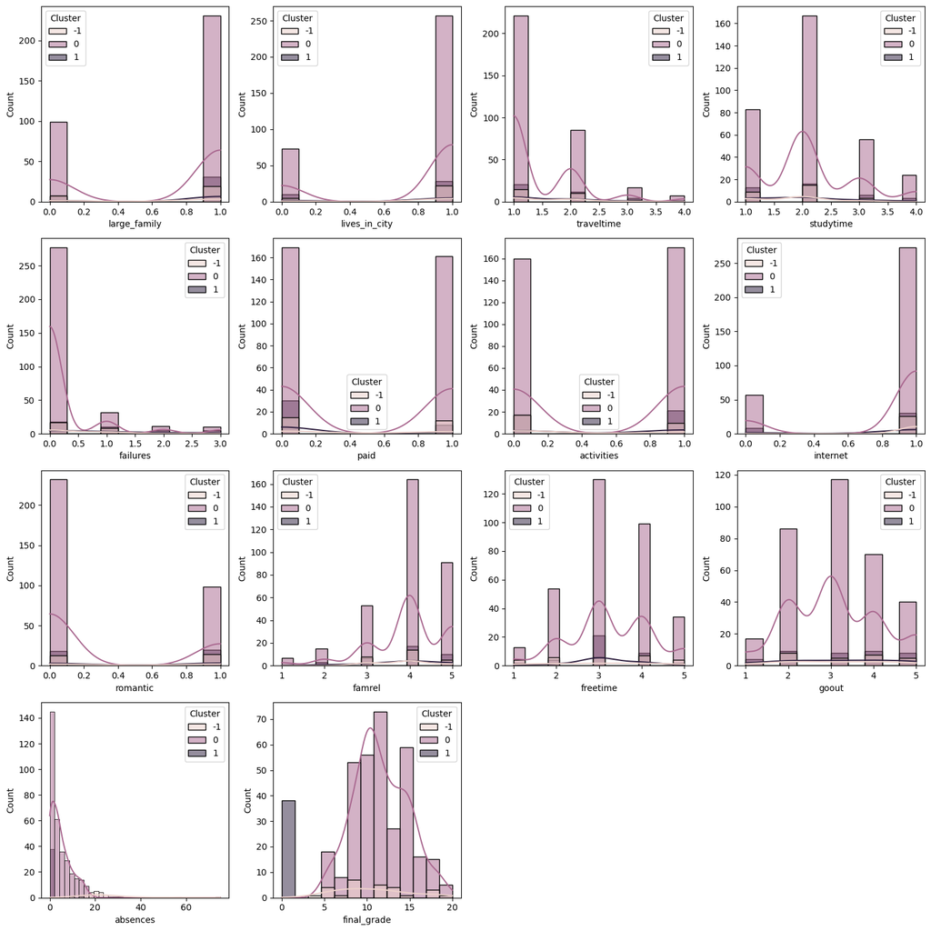

```python
plt.figure(figsize=(15,15))
for i,colname in enumerate(combined_df_clustering2.columns[:-1]):
    plt.subplot(4,4,i+1)
    sns.histplot(data=combined_df_clustering2,x=colname,hue='Cluster',kde=True)
    plt.tight_layout()
```

It is clear from the distribution plots, that the most discriminatory variables in this case are :

- **final_grade**
- **absences**
- **failures**

Lets plot these variables against final_grade to have some understanding of the cluster formation using this technique.

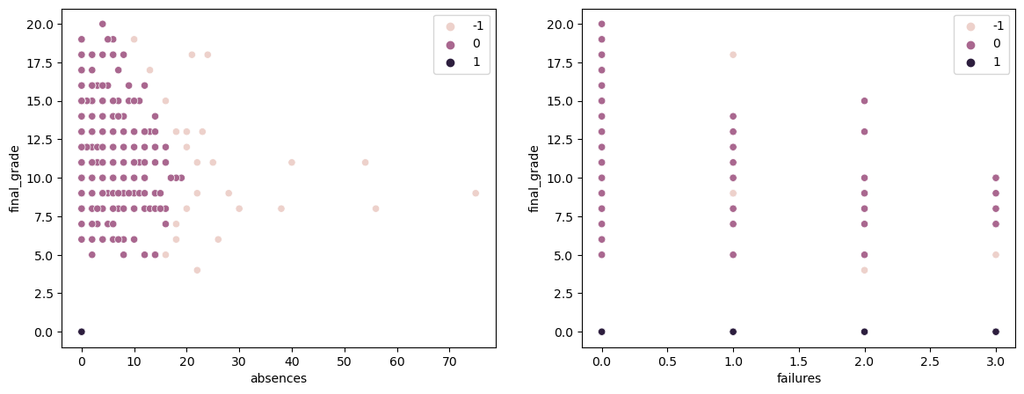

```python
discriminatory_cols=['absences','failures']
plt.figure(figsize=(14,5))
for i,col in enumerate(discriminatory_cols):
    plt.subplot(1,2,i+1)
    sns.scatterplot(data=combined_df_clustering2,x=col,y='final_grade',hue='Cluster').legend(loc='upper right')
plt.show()
```

- As clear from the output above, the only interpretable scatterplot which is showing clustering clearly is the first graph, which is expected because all the second discriminatory variables is discrete in nature.
- Furthermore, distinct cluster formations can be seen in the first plot which suggests that the dataset contains multiple categories of students with different characteristics.